# Holmusk take-home challenge

Chuck

12 January, 2024 (Fri)

### 0.0.2 A large majority of patients are prescribed antidepressants or psychotherapy

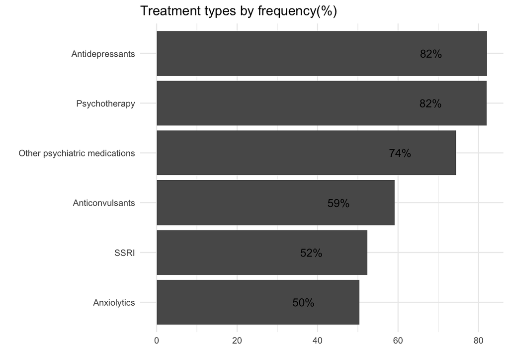

### 0.0.3 Most patients are treated through multiple means

- Treatment with a combination of classes is common, with 92% of the treated receiving ≥3 different classes of therapy, and a 70% of the treated receiving 4 or more. This is likely because individuals who do not respond to an antidepressant therapy may be co-prescribed an adjunctive medication (e.g., anticonvulsant) alongside their antidepressant to help improve their symptoms.
- Accordingly, the average bill amount and improvement in CGI-Severity (CGIS) score is slightly increasing with the number of treatments.

| Number of Treatments | Count | Average Bill Amount | Decrease in CGIS Score |
| --- | --- | --- | --- |
| 0 | 2 (0%) | $22,350 | 0.00 |
| 1 | 49 (1%) | $20,698 | 0.37 |
| 2 | 246 (7%) | $20,986 | 0.37 |
| 3 | 748 (22%) | $21,715 | 0.34 |
| 4 | 1227 (36%) | $21,804 | 0.35 |
| 5 | 851 (25%) | $21,946 | 0.42 |
| 6 | 277 (8%) | $23,203 | 0.43 |

### 0.0.4 No particular class of treatment is predominantly used given patients’ medical histories. This likely reflects the synthetic nature of the data.

| History | Anxiolytics No | Anxiolytics Yes | Anticonvulsants No | Anticonvulsants Yes | Antidepressants No | Antidepressants Yes | SSRI No | SSRI Yes | Psychotherapy No | Psychotherapy Yes | Other psychiatric medications No | Other psychiatric medications Yes |
| --- | --- | --- | --- | --- | --- | --- | --- | --- | --- | --- | --- | --- |
| Diagnosis of diabetes in the past 24 months | 0.17 (0.38) | 0.17 (0.37) | 0.17 (0.37) | 0.17 (0.37) | 0.17 (0.37) | 0.17 (0.38) | 0.17 (0.38) | 0.17 (0.37) | 0.17 (0.37) | 0.17 (0.38) | 0.19 (0.39) | 0.16 (0.37) |
| Diagnosis of substance use disorder in the past 24 months | 0.3 (0.46) | 0.33 (0.47) | 0.3 (0.46) | 0.32 (0.47) | 0.32 (0.47) | 0.31 (0.46) | 0.31 (0.46) | 0.31 (0.46) | 0.33 (0.47) | 0.31 (0.46) | 0.29 (0.46) | 0.32 (0.47) |
| Diagnosis of high blood pressure in the past 24 months | 0.14 (0.35) | 0.13 (0.34) | 0.13 (0.34) | 0.14 (0.35) | 0.12 (0.33) | 0.14 (0.35) | 0.14 (0.34) | 0.14 (0.34) | 0.15 (0.36) | 0.13 (0.34) | 0.15 (0.36) | 0.13 (0.34) |
| Diagnosis of renal failure in the past 24 months | 0.06 (0.24) | 0.04 (0.21) | 0.05 (0.23) | 0.05 (0.22) | 0.05 (0.21) | 0.05 (0.22) | 0.06 (0.23) | 0.05 (0.21) | 0.04 (0.21) | 0.05 (0.23) | 0.05 (0.21) | 0.05 (0.23) |
| Diagnosis of solid tumor in the past 24 months | 0.06 (0.24) | 0.06 (0.25) | 0.07 (0.25) | 0.06 (0.24) | 0.07 (0.25) | 0.06 (0.24) | 0.06 (0.24) | 0.07 (0.25) | 0.06 (0.23) | 0.07 (0.25) | 0.06 (0.23) | 0.07 (0.25) |
| Diagnosis of anxiety disorder in the past 24 months | 0.25 (0.43) | 0.26 (0.44) | 0.24 (0.43) | 0.27 (0.44) | 0.29 (0.45) | 0.25 (0.43) | 0.26 (0.44) | 0.25 (0.44) | 0.25 (0.43) | 0.26 (0.44) | 0.27 (0.44) | 0.25 (0.43) |
| Diagnosis of other mood disorders in the past 24 months | 0.25 (0.43) | 0.26 (0.44) | 0.25 (0.43) | 0.26 (0.44) | 0.25 (0.43) | 0.26 (0.44) | 0.24 (0.42) | 0.27 (0.45) | 0.27 (0.45) | 0.25 (0.43) | 0.27 (0.45) | 0.25 (0.43) |

Mean and standard deviation (in parentheses) of medical history indicators by treatment class

### 0.0.5 Similarly, no particular class of treatment is predominantly used given patients’ symptoms.

| Yes | Anxiolytics No | Anxiolytics Yes | Anticonvulsants No | Anticonvulsants Yes | Antidepressants No | Antidepressants Yes | SSRI No | SSRI Yes | Psychotherapy No | Psychotherapy Yes | Other psychiatric medications No | Other psychiatric medications Yes |
| --- | --- | --- | --- | --- | --- | --- | --- | --- | --- | --- | --- | --- |
| Current presence of abnormal sleep patterns | 0.61 (0.49) | 0.63 (0.48) | 0.61 (0.49) | 0.63 (0.48) | 0.62 (0.49) | 0.62 (0.49) | 0.62 (0.49) | 0.62 (0.49) | 0.63 (0.48) | 0.62 (0.49) | 0.59 (0.49) | 0.63 (0.48) |
| Current presence of anhedonia | 0.66 (0.47) | 0.66 (0.47) | 0.65 (0.48) | 0.67 (0.47) | 0.64 (0.48) | 0.67 (0.47) | 0.65 (0.48) | 0.67 (0.47) | 0.65 (0.48) | 0.66 (0.47) | 0.66 (0.47) | 0.66 (0.47) |
| Current ppoor appetite | 0.56 (0.5) | 0.53 (0.5) | 0.54 (0.5) | 0.55 (0.5) | 0.56 (0.5) | 0.54 (0.5) | 0.54 (0.5) | 0.54 (0.5) | 0.54 (0.5) | 0.55 (0.5) | 0.56 (0.5) | 0.54 (0.5) |
| Currently feeling depressed or hopeless | 0.71 (0.45) | 0.74 (0.44) | 0.74 (0.44) | 0.72 (0.45) | 0.73 (0.45) | 0.73 (0.45) | 0.71 (0.46) | 0.74 (0.44) | 0.7 (0.46) | 0.73 (0.44) | 0.72 (0.45) | 0.73 (0.44) |
| Current presence of suicidal thoughts | 0.52 (0.5) | 0.54 (0.5) | 0.52 (0.5) | 0.53 (0.5) | 0.53 (0.5) | 0.53 (0.5) | 0.53 (0.5) | 0.52 (0.5) | 0.55 (0.5) | 0.52 (0.5) | 0.52 (0.5) | 0.53 (0.5) |

Mean and standard deviation (in parentheses) of symptoms by treatment class

### 0.0.6 I use a regression-based strategy to uncover whether the use of other lines of treatment in addition to the use of antidepressants is associated with improved patient outcomes.

- My preferred specification takes the form of a Chow test, where the interaction term between antidepressants and all other treatments can be interpreted as the incremental gains associated with multiple lines of treatment.
- The outcomes of interest are CGIS scores at the point of discharge, length of stay, and billing amount.
- I control for medical history, gender, age and CGIS scores at the point of admission, all of which could affect the outcome variables independently of treatment.
- Formally, the regression specification is:

$$\begin{equation} \text{Outcome}_{i} =
\beta_0 + \beta_1Antidepressants + \beta_2Controls +
\sum_{i=1}^{5}\gamma_i \text{Other treatments}_{i} +
\sum_{q=1}^{5}\gamma_q \text{Antidepressants}_{q} \text{Other
treatments}_{i} + \varepsilon_{i} \end{equation}$$

Where:

- Gamma_q is the main variable of interest, capturing the incremental effect of using antidepressants alongside any other lines of treatments.

The model can be further extended to test for other interactions between treatment pairs, or even higher-order interactions between treatments.

### 0.0.7 Psychotherapy alone is associated with substantially smaller bill amounts (-2,681).

|  | Length of Stay | CGIS discharge | Bill amount |
| --- | --- | --- | --- |
| (Intercept) | 11.243 *** | 3.390 *** | 7063.338 *** |
|  | (0.508) | (0.185) | (1652.113) |
| Anxiolytics | -0.303 | 0.052 | 293.366 |
|  | (0.254) | (0.092) | (823.928) |
| Anticonvulsants | -0.318 | 0.116 | 484.119 |
|  | (0.259) | (0.094) | (842.039) |
| Antidepressants | -0.374 | 0.130 | -2022.878 |
|  | (0.476) | (0.173) | (1545.426) |
| SSRI | 0.137 | 0.045 | 719.959 |
|  | (0.253) | (0.092) | (823.190) |
| Psychotherapy | 0.052 | 0.113 | -2680.991 ** |
|  | (0.320) | (0.116) | (1039.694) |
| Other psychiatric medications | -0.135 | -0.099 | 216.127 |
|  | (0.294) | (0.107) | (956.717) |
| Anxiolytics:Antidepressants | 0.353 | -0.086 | 202.795 |
|  | (0.279) | (0.102) | (908.000) |
| Anticonvulsants:Antidepressants | 0.095 | -0.121 | 213.991 |
|  | (0.285) | (0.104) | (926.985) |
| Antidepressants:SSRI | -0.123 | -0.056 | -216.518 |
|  | (0.279) | (0.101) | (907.135) |
| Antidepressants:Psychotherapy | 0.108 | -0.151 | 2726.613 * |
|  | (0.356) | (0.129) | (1157.099) |
| Antidepressants:Other psychiatric medications | 0.254 | 0.170 | 307.321 |
|  | (0.324) | (0.118) | (1053.424) |
| Controls for medical history, gender, age and CGIS scores at the point of admission | Yes | Yes | Yes |
| *** p < 0.001; ** p < 0.01; * p < 0.05. Robust standard errors in brackets. |  |  |  |

### 0.0.8 Limitations and extensions

- A longer period of observation will allow for us to better observe the effect of multiple lines of therapy, through several channels. First, we could observe longer-term outcomes such as re-admission rates. Second, we could explore changes in treatment for the same individual over time. This may also allow for alternate models such as those which which control for individual fixed effects.
- Better classification of drug data will allow us to construct features for treatment intensity and possibly even sequencing of treatments.
- The coverage of real-world data provide generality to a broad cross-section of the population and reflects actual prescribing practices. This study therefore fills gaps on pharmacological treatment patterns of patients diagnosed with MDD and the role that adjunctive therapy plays.